# How to leverage R in data science

郭耀仁 Yao-Jen Kuo

2019-12-18

## Agenda

- Recap: A Typical Data Science Project
- Import
- Tidy and Transform
- Visualise
- Model
- Communicate
- Tips for a self-taught machine learning engineer

# Recap: A Typical Data Science Project

## A typical data science project looks like this

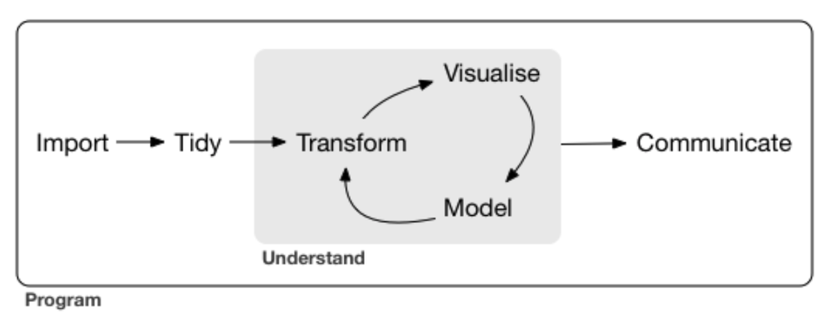

## In this session, we will show you how to leverage R in every step by completing 3 beginner contests in Kaggle

## First things first, what is Kaggle anyway

> Kaggle is an online community of data scientists and machine learners.

Source: https://en.wikipedia.org/wiki/Kaggle

## You can sign up your kaggle account easily

https://www.kaggle.com/account/login

## What to do after signing up?

- [Learn](https://www.kaggle.com/learn)
- [Competitions](https://www.kaggle.com/competitions)
- [Discussion](https://www.kaggle.com/discussion)

## How to learn Kaggle

https://www.kaggle.com/learn/overview

## Kaggle Competitions are its core assets

## There are 7 categories in Kaggle Competitions

- Featured
- Research
- Recruitment
- Getting started
- Masters
- Playground
- Analytics

## 3 competitions to get started

- [House Prices: Advanced Regression Techniques](https://www.kaggle.com/c/house-prices-advanced-regression-techniques)
- [Titanic: Machine Learning from Disaster](https://www.kaggle.com/c/titanic)
- [Digit Recognizer](https://www.kaggle.com/c/digit-recognizer)

## Okay, get the prerequisites done in R

## Packages to install

```r
packages_to_install <- c("dplyr", "ggplot2", "caret", "rpart", "randomForest")
install.packages(packages_to_install)
```

## Packages to library

```r
library("dplyr")
library("ggplot2")
library("caret")
library("rpart")
library("randomForest")
```

# Import

## Titanic: Machine Learning from Disaster

```r
train <- read.csv("https://s3-ap-northeast-1.amazonaws.com/kaggle-getting-started/titanic/train.csv", stringsAsFactors = FALSE)
test <- read.csv("https://s3-ap-northeast-1.amazonaws.com/kaggle-getting-started/titanic/test.csv", stringsAsFactors = FALSE)
titanic <- list(
  train =  train,
  test = test
)
```

## House Prices: Advanced Regression Techniques

```r
train <- read.csv("https://s3-ap-northeast-1.amazonaws.com/kaggle-getting-started/house-prices/train.csv", stringsAsFactors = FALSE)
test <- read.csv("https://s3-ap-northeast-1.amazonaws.com/kaggle-getting-started/house-prices/test.csv", stringsAsFactors = FALSE)
housing <- list(
  train =  train,
  test = test
)
```

## Digit Recognizer

```r
train <- read.csv("https://s3-ap-northeast-1.amazonaws.com/kaggle-getting-started/mnist/train.csv", stringsAsFactors = FALSE)
test <- read.csv("https://s3-ap-northeast-1.amazonaws.com/kaggle-getting-started/mnist/test.csv", stringsAsFactors = FALSE)
mnist <- list(
  train = train,
  test = test
)
```

## Exploring more on “Import”

- [Getting started with httr](https://cran.r-project.org/web/packages/httr/vignettes/quickstart.html)
- rvest
- jsonlite
- [readxl](https://readxl.tidyverse.org/)
- [readr](https://readr.tidyverse.org/)
- [Databases using R](https://db.rstudio.com/)

# Tidy and Transform

## Titanic and House Prices are both suitable for practicing the skills of feature engineering

- Log transformation
- Standardization
- One-hot encoding
- Matrix manipulation
- …etc.

## House `SalePrice` BEFORE log transformation

```r
p <- ggplot(housing$train, aes(x = SalePrice)) +
  geom_histogram(bins=100)
```

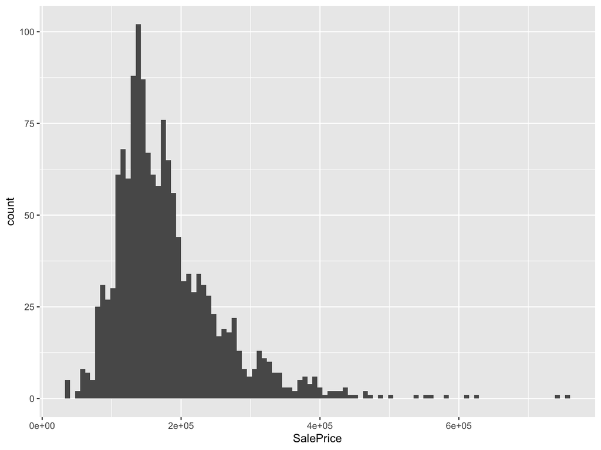

```r
p
```

## House `SalePrice` AFTER log transformation

```r
p <- ggplot(housing$train, aes(x = SalePrice)) +
  geom_histogram(bins=100) +
  scale_x_log10()
```

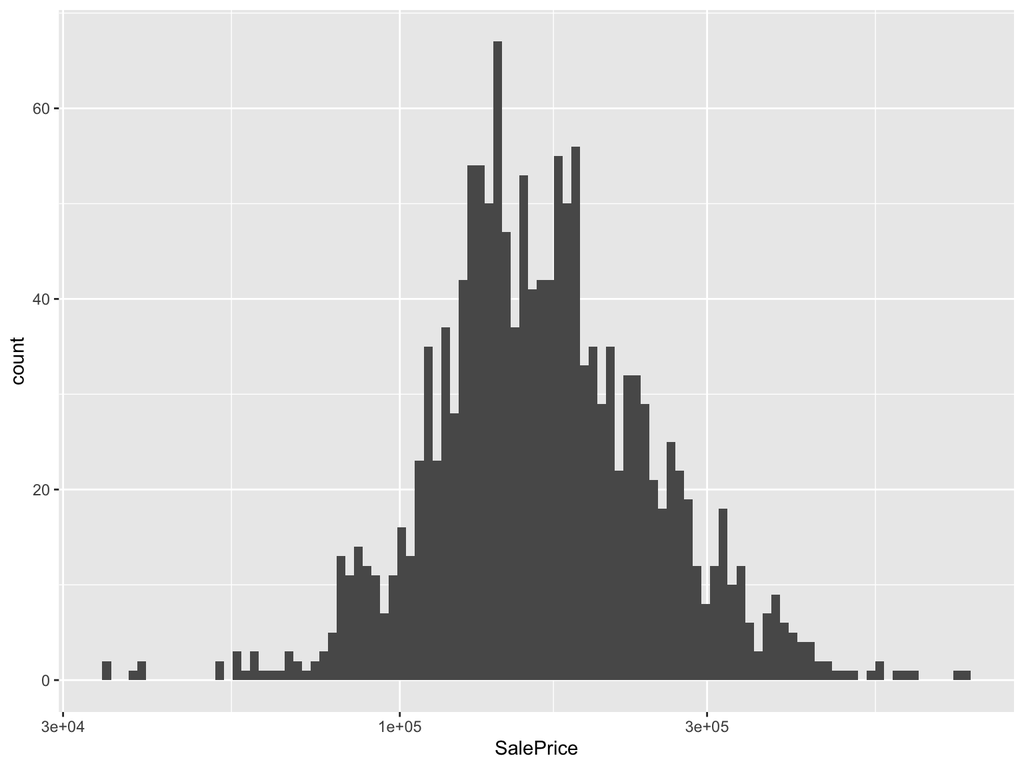

```r
p
```

## We can have a more LINEAR relationship via log transformation

```r
p <- ggplot(housing$train, aes(x = GrLivArea, y = SalePrice)) +
  geom_point() +
  scale_x_log10() +
  scale_y_log10()
```

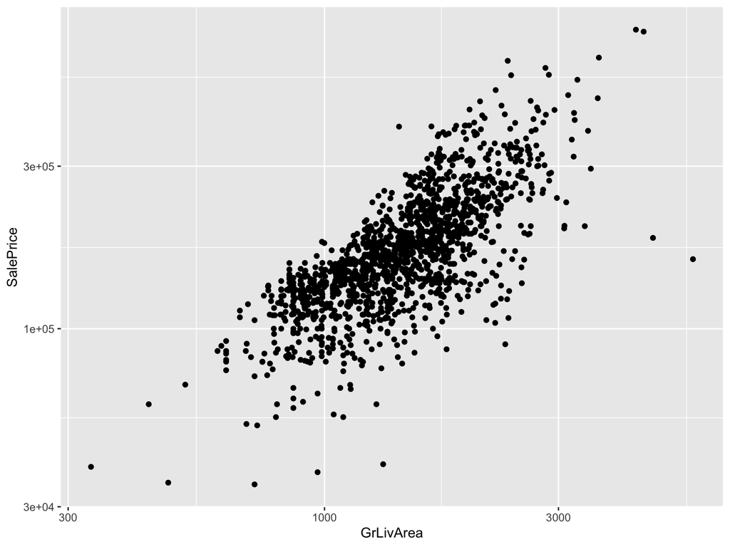

```r
p
```

## Titanic passenger `Fare` BEFORE standardization

```r
p <- ggplot(titanic$train, aes(x = Fare)) +
  geom_histogram(bins = 100)
```

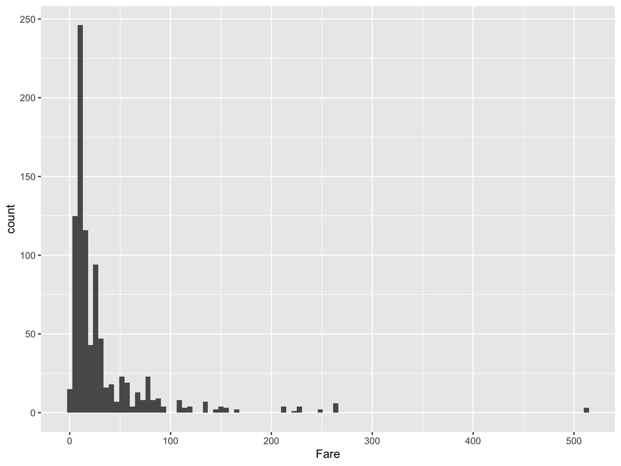

```r
p
```

## Titanic passenger `Fare` AFTER standardization

```r
mean_fare <- mean(titanic$train$Fare)
std_fare <- sd(titanic$train$Fare)
titanic$train$FareStandardized <- (titanic$train$Fare - mean_fare)/std_fare
p <- ggplot(titanic$train, aes(x = FareStandardized)) +
  geom_histogram(bins = 100)
```

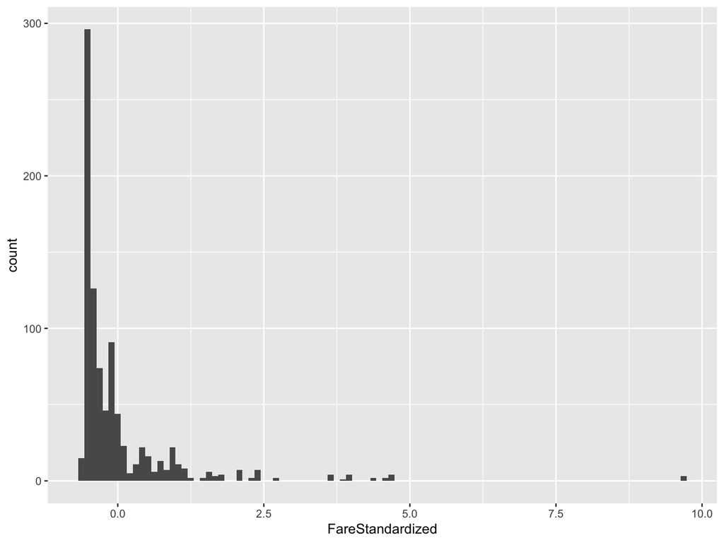

```r
p
```

## Titanic passenger `Embarked` BEFORE One Hot Encoding

```r
titanic$train$Embarked[1:10]
```

```
##  [1] "S" "C" "S" "S" "S" "Q" "S" "S" "S" "C"
```

## Titanic passenger `Embarked` AFTER One Hot Encoding

```r
library(caret)

dummy <- dummyVars(" ~ Embarked", data = titanic$train, fullRank = TRUE)
ohe_Embarked <- data.frame(predict(dummy, newdata = titanic$train))
ohe_Embarked[1:10, ]
```

```
##    EmbarkedC EmbarkedQ EmbarkedS
## 1          0         0         1
## 2          1         0         0
## 3          0         0         1
## 4          0         0         1
## 5          0         0         1
## 6          0         1         0
## 7          0         0         1
## 8          0         0         1
## 9          0         0         1
## 10         1         0         0
```

## Digit recognizer BEFORE matrix manipulation

```r
mnist$train[1, 2:ncol(mnist$train)]
```

[output not shown]

[output cut: 139 more lines]

[output not shown]

## Digit recognizer AFTER matrix manipulation

```r
first_image <- as.integer(mnist$train[1, 2:ncol(mnist$train)])
first_image_matrix <- matrix(first_image, nrow=28)
first_image_matrix
```

```
##       [,1] [,2] [,3] [,4] [,5] [,6] [,7] [,8] [,9] [,10] [,11] [,12] [,13]
##  [1,]    0    0    0    0    0    0    0    0    0     0     0     0     0
##  [2,]    0    0    0    0    0    0    0    0    0     0     0     0     0
##  [3,]    0    0    0    0    0    0    0    0    0     0     0     0     0
##  [4,]    0    0    0    0    0    0    0    0    0     0     0     0     0
##  [5,]    0    0    0    0    0    0    0    0    0     0     0     0     0
##  [6,]    0    0    0    0    0    0    0    0    0     0     0     0     0
##  [7,]    0    0    0    0    0    0    0    0    0     0     0     0     0
##  [8,]    0    0    0    0    0    0    0    0    0     0     0     0     0
##  [9,]    0    0    0    0    0    0    0    0    0     0     0     0     0
## [10,]    0    0    0    0    0    0    0    0    0     0     0     0     0
## [11,]    0    0    0    0    0    0    0    0    0     0     0     0     0
## [12,]    0    0    0    0    0    0    0    0    0     0     0     0     0
## [13,]    0    0    0    0    0    0    0    0    0     0     0     0    16
## [14,]    0    0    0    0    0    0    0    0    0     0     0    23   209
```

[output cut: 72 more lines]

## Exploring more on “Tidy and Transform”

- [`dplyr`](https://dplyr.tidyverse.org/)
- [`tidyr`](https://tidyr.tidyverse.org/)
- [The `caret` Package](http://topepo.github.io/caret/index.html)

# Visualise

## Exploring data insights via different types of plot

- Using scatter for correlations
- Using histogram for distributions
- Using bar for rankings
- Using image for pixel matrice
- …etc.

## Exploring correlations between House `SalePrice` and `GrLivArea`

```r
p <- ggplot(housing$train, aes(x = GrLivArea, y = SalePrice)) +
  geom_point()
```

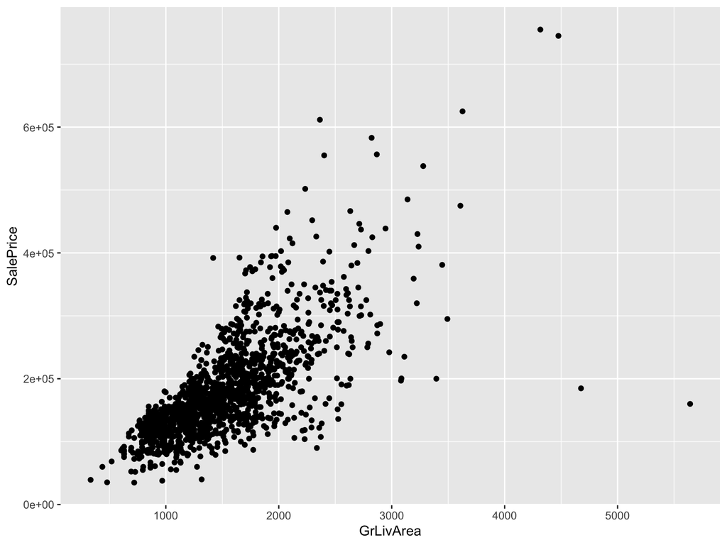

```r
p
```

## Exploring distribution with House `SalePrice`

```r
p <- ggplot(housing$train, aes(x = SalePrice)) +
  geom_histogram(bins=100)
```

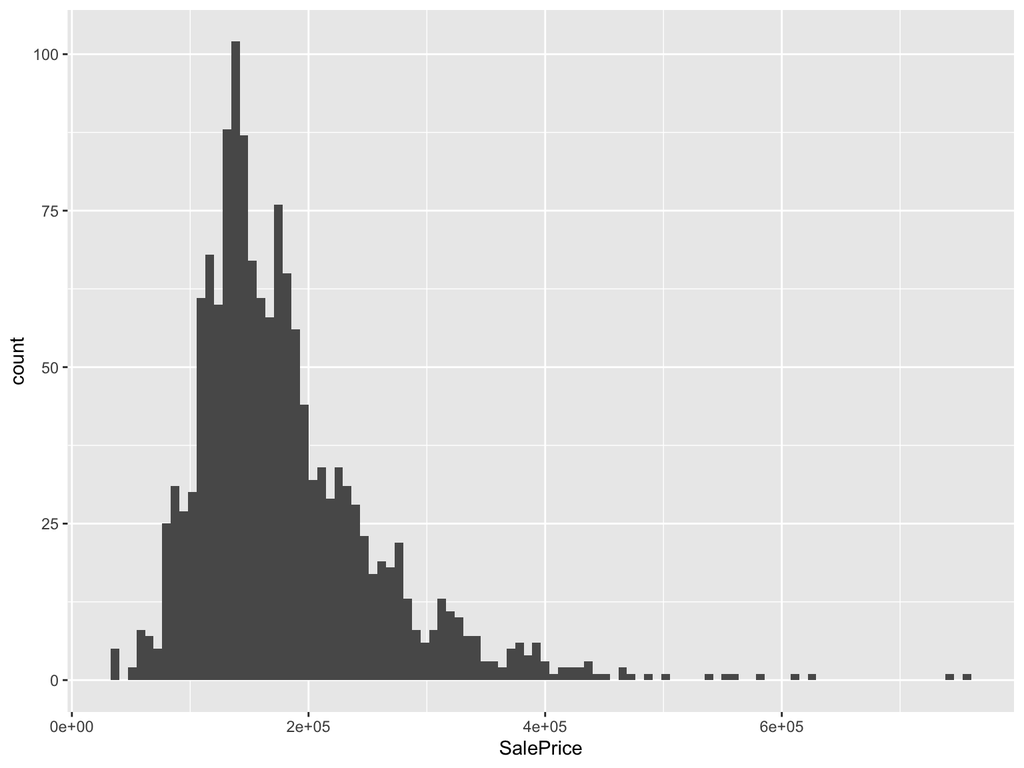

```r
p
```

## Exploring rankings with Titanic `Embarked`

```r
p <- ggplot(titanic$train, aes(x = Embarked, fill=Embarked)) +
  geom_bar()
```

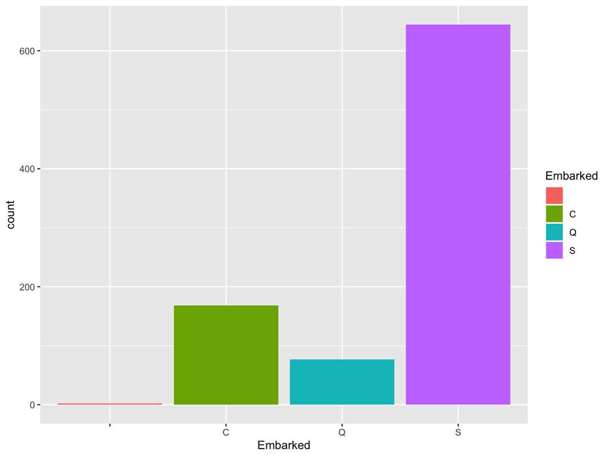

```r
p
```

## Visualising a pixel matrix

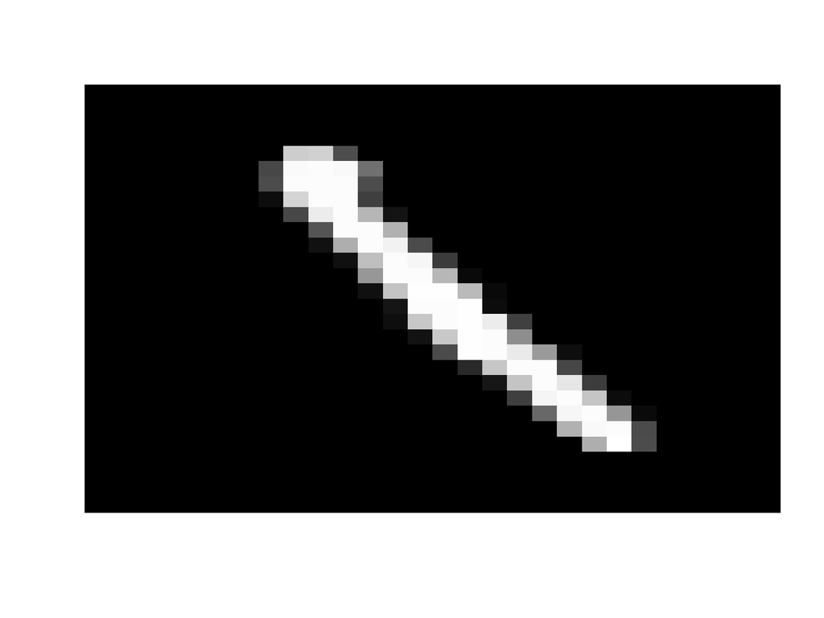

```r
image(first_image_matrix, axes=FALSE, useRaster = TRUE, col=gray((0:255)/255))
```

## Exploring more on “Visualize”

- [ggplot2](https://ggplot2.tidyverse.org/)
- [plotly](https://plot.ly/r/)
- [Shiny](https://shiny.rstudio.com/)

# Model

## Predicting `SalePrice` for Housing `test`

```r
# data manipulation
test_labels <- housing$test$Id
housing$test$Id <- NULL
housing$train$Id <- NULL
housing$test$SalePrice <- NA
train_test <- rbind(housing$train, housing$test)
numericVars <- which(sapply(train_test, is.numeric))
factorVars <- which(sapply(train_test, is.factor))
all_numVar <- train_test[, numericVars]
cor_numVar <- cor(all_numVar, use = "pairwise.complete.obs")
cor_sorted <- as.matrix(sort(cor_numVar[, 'SalePrice'], decreasing = TRUE))
CorHigh <- names(which(apply(cor_sorted, 1, function(x) abs(x)>0.5)))
cor_numVar <- cor_numVar[CorHigh, CorHigh]
cor_high_vars <- names(cor_numVar[, 1])
combined <- train_test[, cor_high_vars]
```

```r
# modeling
train1 <- combined[!is.na(train_test$SalePrice), ]
test1 <- combined[is.na(train_test$SalePrice), ]
test1 <- test1[, -1]
lm_fit <- lm(formula = SalePrice ~ ., data = train1)
# predicting
y_pred <- predict(lm_fit, test1)
# replace NA if there is any
y_pred[is.na(y_pred)] <- mean(y_pred, na.rm = TRUE)
y_pred[1:10]
```

```
##     1461     1462     1463     1464     1465     1466     1467     1468
## 110135.9 159060.0 169683.7 188059.7 219782.0 182152.0 175453.9 175115.2
##     1469     1470
## 210229.8 102017.8
```

## Preparing submission for Housing

```r
submission <- data.frame(
  Id = as.integer(row.names(test1)),
  SalePrice = y_pred
)
write.csv(submission, row.names = FALSE, file = 'housing_submission.csv')
```

## Predicting `Survived` for Titanic `test`

```r
# data manipulation
titanic$test$Survived <- NA
train_test <- bind_rows(titanic$train, titanic$test)
train_test$Embarked[c(62, 830)] <- 'C'
train_test$Fare[1044] <- median(train_test[train_test$Pclass == '3' & train_test$Embarked == 'S', ]$Fare, na.rm = TRUE)
age_missing <- is.na(train_test$Age)
train_test$Age[age_missing] <- median(train_test$Age, na.rm = TRUE)
```

```r
# modeling
train1 <- train_test[1:891, ]
test1 <- train_test[892:nrow(train_test), ]
dt_model <- rpart(formula = factor(Survived) ~ Pclass + Sex + Age + SibSp + Parch + Fare + Embarked, data = train1)

# predicting
y_pred <- predict(dt_model, test1[, c('Pclass', 'Sex', 'Age', 'SibSp', 'Parch', 'Fare', 'Embarked')], type = "class")
```

## Preparing submission for Titanic

```r
submission <- data.frame(
  PassengerId = as.integer(row.names(test1)),
  Survived = y_pred
)
write.csv(submission, row.names = FALSE, file = 'titanic_submission.csv')
```

## Predicting `label` for MNIST `test`

```r
# data manipulation
numTrain <- 10000
numTrees <- 25
rows <- sample(1:nrow(mnist$train), numTrain)
labels <- as.factor(mnist$train[rows,1])
train <- mnist$train[rows, -1]
```

```r
# modeling
rf <- randomForest(train, labels, xtest = mnist$test, ntree = numTrees)
# predicting
y_pred <- rf$test$predicted
```

## Preparing submission for MNIST

```r
submission <- data.frame(
  PassengerId = as.integer(row.names(mnist$test)),
  Survived = y_pred
)
write.csv(submission, row.names = FALSE, file = 'mnist_submission.csv')
```

## Exploring more on “Model”

- [XGBoost R Package](https://xgboost.readthedocs.io/en/latest/R-package/index.html)

# Communicate

## Actually, the slides we’ve been used are generated with R

## Using a variety of document formats to communicate with your colleagues

- HTML
- PDF
- Word
- PowerPoint
- Shiny

## Exploring more on “Communicate”

- [blogdown](https://bookdown.org/yihui/blogdown/)
- [bookdown](https://bookdown.org/yihui/bookdown/)
- [Shiny](https://shiny.rstudio.com/)

# Tips for a self-taught machine learning engineer

## Recap: the Venn-diagram of data science

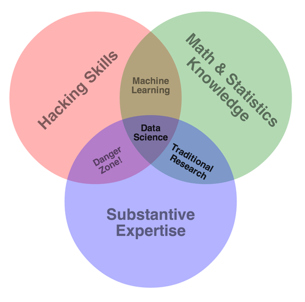

## A quote from Shane Legg’s tweet

> Learn: 1. linear algebra well (e.g. matrix math) 2. calculus to an ok level (not advanced stuff) 3. prob. theory and stats to a good level 4. theoretical computer science basics 5. to code well in Python and ok in C++ Then read and implement ML papers and *play* with stuff! :-)

Source: https://twitter.com/ShaneLegg/status/1024289820665950208?s=20